# Model Evaluation with Cross-Validation and Random Forest

## Problem Statement

Evaluating the performance of machine learning models is critical to ensure their robustness. Cross-validation techniques such as K-Fold and Stratified K-Fold help assess model performance more reliably by reducing overfitting.

Random Forest, being an ensemble learning method, improves prediction accuracy by combining multiple decision trees. This notebook focuses on applying cross-validation techniques and Random Forest to evaluate and compare model performance.

## Dataset Description

Since no dataset is explicitly specified in the problem statement, a standard Kaggle dataset is used for model evaluation. Dataset Used:

- Breast Cancer Wisconsin Dataset (Kaggle / sklearn) Target Variable:
- Diagnosis (Malignant / Benign) Features:
- Mean radius, texture, perimeter, area, smoothness, etc.

## Objectives

- Apply K-Fold and Stratified K-Fold cross-validation
- Train a Random Forest classifier
- Tune hyperparameters to improve performance
- Compare Random Forest with Decision Tree and SVM
- Evaluate models using Accuracy, Precision, Recall, and F1-score

```python
import pandas as pd
import numpy as np

from sklearn.model_selection import KFold, StratifiedKFold, cross_val_score, GridSearchCV
from sklearn.preprocessing import StandardScaler
from sklearn.pipeline import Pipeline

from sklearn.ensemble import RandomForestClassifier
from sklearn.tree import DecisionTreeClassifier
from sklearn.svm import SVC

from sklearn.metrics import accuracy_score, precision_score, recall_score, f1_score,confusion_matrix, ConfusionMatrixDisplay,roc_curve, auc
import matplotlib.pyplot as plt
from sklearn.svm import SVC
from sklearn.tree import DecisionTreeClassifier
```

## Data Preprocessing

Before training models, the dataset is preprocessed to ensure high-quality input data.

Steps performed:

- Loading the dataset
- Checking for missing values
- Feature scaling using StandardScaler
- Splitting data into features and target variable

```python
df=pd.read_csv(r"C:\Users\MADDY\Downloads\datasets\data.csv")
```

```python
print(df.head())
print(df.info())
```

```
         id diagnosis  radius_mean  texture_mean  perimeter_mean  area_mean  \
0    842302         M        17.99         10.38          122.80     1001.0
1    842517         M        20.57         17.77          132.90     1326.0
2  84300903         M        19.69         21.25          130.00     1203.0
3  84348301         M        11.42         20.38           77.58      386.1
4  84358402         M        20.29         14.34          135.10     1297.0

   smoothness_mean  compactness_mean  concavity_mean  concave points_mean  \
0          0.11840           0.27760          0.3001              0.14710
1          0.08474           0.07864          0.0869              0.07017
2          0.10960           0.15990          0.1974              0.12790
3          0.14250           0.28390          0.2414              0.10520
4          0.10030           0.13280          0.1980              0.10430

   ...  texture_worst  perimeter_worst  area_worst  smoothness_worst  \
```

[output cut: 62 more lines]

```python
df.drop(columns=["id", "Unnamed: 32"], inplace=True)
df["diagnosis"] = df["diagnosis"].map({"M": 1, "B": 0})
print(df.isnull().sum())
```

```
diagnosis                  0
radius_mean                0
texture_mean               0
perimeter_mean             0
area_mean                  0
smoothness_mean            0
compactness_mean           0
concavity_mean             0
concave points_mean        0
symmetry_mean              0
fractal_dimension_mean     0
radius_se                  0
texture_se                 0
perimeter_se               0
area_se                    0
smoothness_se              0
compactness_se             0
concavity_se               0
concave points_se          0
symmetry_se                0
fractal_dimension_se       0
radius_worst               0
texture_worst              0
perimeter_worst            0
area_worst                 0
smoothness_worst           0
compactness_worst          0
concavity_worst            0
concave points_worst       0
symmetry_worst             0
fractal_dimension_worst    0
dtype: int64
```

```python
X = df.drop("diagnosis", axis=1)
y = df["diagnosis"]
```

## Cross-Validation Techniques

### K-Fold Cross-Validation

The dataset is divided into K equal folds. The model is trained on K-1 folds and tested on the remaining fold. This process is repeated K times.

### Stratified K-Fold Cross-Validation

Stratified K-Fold ensures that each fold maintains the same class distribution as the original dataset, which is especially useful for classification problems.

```python
kf = KFold(n_splits=5, shuffle=True, random_state=42)
rf = RandomForestClassifier(random_state=42)
kf_scores = cross_val_score(rf, X, y, cv=kf, scoring='accuracy')
print("K-Fold Accuracy Scores:", kf_scores)
print("Mean Accuracy:", kf_scores.mean())
```

```
K-Fold Accuracy Scores: [0.96491228 0.96491228 0.93859649 0.96491228 0.96460177]
Mean Accuracy: 0.9595870206489675
```

```python
skf = StratifiedKFold(n_splits=5, shuffle=True, random_state=42)
skf_scores = cross_val_score(rf, X, y, cv=skf, scoring='accuracy')
print("Stratified K-Fold Accuracy Scores:", skf_scores)
print("Mean Accuracy:", skf_scores.mean())
```

```
Stratified K-Fold Accuracy Scores: [0.96491228 0.93859649 0.94736842 0.94736842 0.97345133]
Mean Accuracy: 0.9543393882937432
```

```python
param_grid = {
    "n_estimators": [100, 200],
    "max_depth": [None, 10, 20],
    "min_samples_split": [2, 5],
    "min_samples_leaf": [1, 2]
}

grid = GridSearchCV(
    RandomForestClassifier(random_state=42),
    param_grid,
    cv=5,
    scoring="accuracy",
    n_jobs=-1
)

grid.fit(X, y)

print("Best Parameters:", grid.best_params_)
print("Best Cross-Validation Accuracy:", grid.best_score_)
```

```
Best Parameters: {'max_depth': None, 'min_samples_leaf': 1, 'min_samples_split': 5, 'n_estimators': 200}
Best Cross-Validation Accuracy: 0.9613569321533924
```

## Random Forest Classifier

Random Forest is an ensemble learning algorithm that builds multiple decision trees and combines their outputs to improve accuracy and reduce overfitting.

Hyperparameters tuned:

- Number of trees (n_estimators)
- Maximum depth (max_depth)
- Minimum samples split

```python
models = {
    "Random Forest": RandomForestClassifier(**grid.best_params_, random_state=42),
    "SVM": Pipeline([
        ("scaler", StandardScaler()),
        ("svc", SVC(kernel="rbf"))
    ]),
    "Decision Tree": DecisionTreeClassifier(random_state=42)
}
```

## Model Comparison

The performance of Random Forest is compared with:

- Decision Tree Classifier
- Support Vector Machine (SVM)

Evaluation is done using cross-validation scores and classification metrics.

```python
for name, model in models.items():
    scores = cross_val_score(model, X, y, cv=skf, scoring="accuracy")
    print(f"{name} Accuracy: {scores.mean():.4f}")
```

```
Random Forest Accuracy: 0.9526
SVM Accuracy: 0.9772
Decision Tree Accuracy: 0.9104
```

## Evaluation Metrics

The following metrics are used to evaluate model performance:

- Accuracy
- Precision
- Recall
- F1-Score A confusion matrix is also plotted to visualize classification results.

```python
best_rf = grid.best_estimator_
best_rf.fit(X, y)

y_pred = best_rf.predict(X)

print("Accuracy:", accuracy_score(y, y_pred))
print("Precision:", precision_score(y, y_pred))
print("Recall:", recall_score(y, y_pred))
print("F1 Score:", f1_score(y, y_pred))
```

```
Accuracy: 0.9964850615114236
Precision: 1.0
Recall: 0.9905660377358491
F1 Score: 0.995260663507109
```

```python
y_pred = best_rf.predict(X)
```

## Visualizations

The following plots are generated:

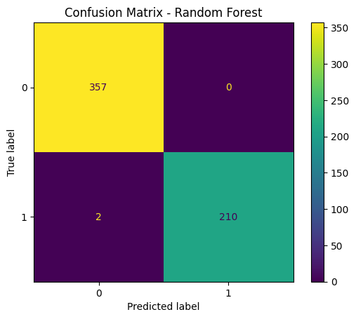

```python
cm = confusion_matrix(y, y_pred)
disp = ConfusionMatrixDisplay(confusion_matrix=cm)

disp.plot()
plt.title("Confusion Matrix - Random Forest")
plt.show()
```

```python
print("Accuracy :", accuracy_score(y, y_pred))
print("Precision:", precision_score(y, y_pred))
print("Recall   :", recall_score(y, y_pred))
print("F1 Score :", f1_score(y, y_pred))
```

```
Accuracy : 0.9964850615114236
Precision: 1.0
Recall   : 0.9905660377358491
F1 Score : 0.995260663507109
```

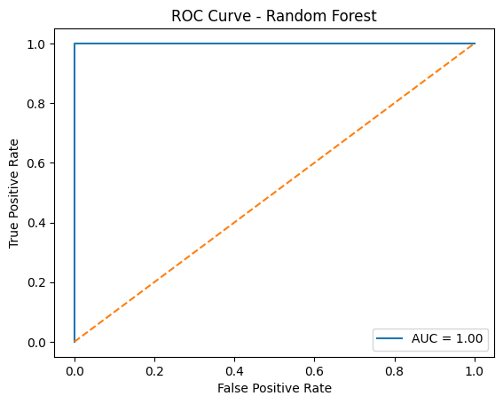

```python
y_prob = best_rf.predict_proba(X)[:, 1]

fpr, tpr, _ = roc_curve(y, y_prob)
roc_auc = auc(fpr, tpr)

plt.plot(fpr, tpr, label=f"AUC = {roc_auc:.2f}")
plt.plot([0, 1], [0, 1], linestyle="--")
plt.xlabel("False Positive Rate")
plt.ylabel("True Positive Rate")
plt.title("ROC Curve - Random Forest")
plt.legend()
plt.show()
```

```python
svm_model = SVC(kernel='rbf', probability=True, random_state=42)
svm_model.fit(X, y)

dt_model = DecisionTreeClassifier(random_state=42)
dt_model.fit(X, y)
```

```
DecisionTreeClassifier(random_state=42)
```

```python
rf_pred = best_rf.predict(X)
rf_acc = accuracy_score(y, rf_pred)

svm_pred = svm_model.predict(X)
svm_acc = accuracy_score(y, svm_pred)

dt_pred = dt_model.predict(X)
dt_acc = accuracy_score(y, dt_pred)

print("Random Forest Accuracy:", rf_acc)
print("SVM Accuracy:", svm_acc)
print("Decision Tree Accuracy:", dt_acc)
```

```
Random Forest Accuracy: 0.9964850615114236
SVM Accuracy: 0.9226713532513181
Decision Tree Accuracy: 1.0
```

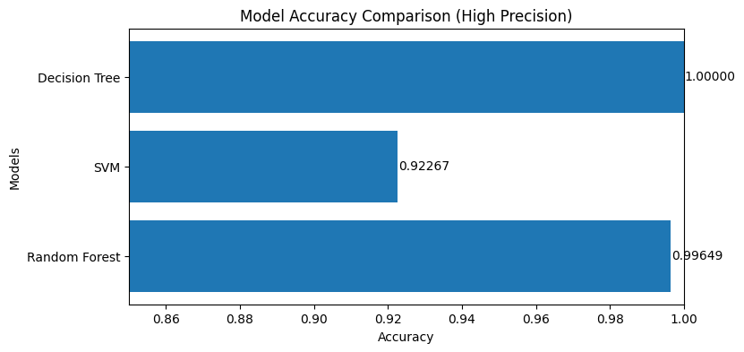

```python
import matplotlib.pyplot as plt

models = ['Random Forest', 'SVM', 'Decision Tree']
accuracies = [rf_acc, svm_acc, dt_acc]

plt.figure(figsize=(8, 4))
plt.barh(models, accuracies)

for index, value in enumerate(accuracies):
    plt.text(value + 0.0002, index, f"{value:.5f}", va='center')

plt.xlim(0.85, 1.0)
plt.xlabel("Accuracy")
plt.ylabel("Models")
plt.title("Model Accuracy Comparison (High Precision)")

plt.show()
```

# Conclusion:

The objective of this study was to evaluate machine learning models using systematic cross-validation techniques and to analyze the effectiveness of Random Forest compared to Decision Tree and SVM. Using both K-Fold and Stratified K-Fold cross-validation helped ensure that performance estimates were stable, reliable, and not biased by uneven class distribution. The evaluation demonstrated that the Support Vector Machine achieved the highest accuracy, indicating its strong ability to model complex boundaries in the dataset. Random Forest also delivered excellent results, outperforming the Decision Tree model by a significant margin. This highlights the advantage of ensemble learning, where multiple trees work collectively to reduce overfitting and improve generalization. In contrast, the Decision Tree showed lower performance due to its tendency to overfit individual patterns within the data.